# Lecture 14: Mixture Models

Bayesian Psychometric Modeling

```r
# Install/Load Packages ===============================================================================================
if (!require(R2jags)) install.packages("R2jags")
```

```
## Linked to JAGS 4.3.0
```

```
## Loaded modules: basemod,bugs
```

```r
library(R2jags)

if (!require(CDM)) install.packages("CDM")
```

```
## ** CDM 7.3-17 (2019-03-18 18:33:40)
## ** Cognitive Diagnostic Models  **
```

```r
library(CDM)

if (!require(MCMCpack)) install.packages("MCMCpack")
```

```
## ##
## ## Markov Chain Monte Carlo Package (MCMCpack)
```

```
## ## Copyright (C) 2003-2019 Andrew D. Martin, Kevin M. Quinn, and Jong Hee Park
```

```
## ##
## ## Support provided by the U.S. National Science Foundation
```

```
## ## (Grants SES-0350646 and SES-0350613)
## ##
```

```r
library(MCMCpack)

if (!require(mcmcplots)) install.packages("mcmcplots")
library(mcmcplots)

set.seed(23042019)
FSdata = fraction.subtraction.data
FSQmatrix = fraction.subtraction.qmatrix
```

## Mixture Models for Binary Data: Example Analyses

We will use the Tatsuoka (1984) fraction subtraction data for today’s examples. See DeCarlo (2011, p. 9) for the items: https://scholar.google.com/scholar?hl=en&as_sdt=0%2C36&q=l+decarlo+2011&btnG=.

A finite mixture model can be defined by:

$$f(\boldsymbol{x}_p) = \sum_{c=1}^Cf(\boldsymbol{x}_p|c)f(c) = \sum_{c=1}^C \eta_c f(\boldsymbol{x}_p|c),$$
where: - $\boldsymbol{x}_p$ is a vector of observed responses for person $p$ - $C$ is the total number of classes - $f(\boldsymbol{x}_p)$ is the marginal distribution of $\boldsymbol{x}_p$ - $f(\boldsymbol{x}_p|c)$ is the distribution of $\boldsymbol{x}_p$ for class $c$ - $f(c)$ is the marginal distribution for the classes, which is multinomial, with probabilities $\sum_{c=1}^C \eta_c = 1$

First, we will consider a latent class model, which assumes binary resposnes that are independent conditional on class:

$$f(\boldsymbol{x}_p) = \sum_{c=1}^C \eta_c \prod_{i=1}^I \pi_{ic}^{x_{pi}}\left(1 -\pi_{ic} \right)^{1-x_{pi}},$$
where, additionally: - $x_{pi}$ is the $i$th binary item response for person $p$ - $\pi_{ic}$ is the probablity of a correct response to item $i$ in class $c$

Typically, latent class analyses are exploratory models (much like EFA models). So, we have to run a number of models to determine the number of classes in the data, then we will interpret each of the classes.

Here, we will use a Dirichlet distribution (https://en.wikipedia.org/wiki/Dirichlet_distribution) as a prior distribution for $\eta_c$, which is a conjugate prior. Additionally, we will use a Beta(1,1) prior for $\pi_{ic}$, which is also conjugate.

Because this makes my soul die a little, let’s pretend a four-class model fit our data. Here is how to run that analysis:

### Model 1: Four-class LCA Model

```r
# model 1 specs:
nItems = ncol(FSdata)
```

```r
# marker item:
model01.function = function(){

  # measurement model specification
  for (person in 1:N){
    for (item in 1:I){
      X[person, item] ~ dbern(pi[item, xclass[person]])
    }
  }

  # prior distribution for class:
  for (person in 1:N){
    xclass[person] ~ dcat(eta[1:C])
  }

  # prior distribution for class probabilities:
  eta[1:C] ~ ddirich(alpha[1:C])

  for (item in 1:I){
    for (class in 1:C){
      pi[item, class] ~ dbeta(a.0,b.0)
    }
  }

}
```

```r
# set number of classes
C = 4

# set priors for item parameters:
a.0 = 1
b.0 = 1

# set priors for parameters of dirichlet distribution
alpha = rep(1:C)

model01.inits = function(){
  library(MCMCpack)
  list("eta" = rdirichlet(n = 1, alpha = alpha))
}

# next, create data for JAGS to use:
model01.data = list(
  N = nrow(FSdata),
  X = FSdata,
  I = nItems,
  C = C,
  a.0 = a.0,
  b.0 = b.0,
  alpha = alpha
)

model01.parameters = c("pi", "eta",  "xclass")

# for reproducable analyses
model01.seed = 23042019
```

Here, we will use the R2jags `jags.parallel()` function, which will run somewhat faster (one chain per core):

```r
model01.r2jags =  jags.parallel(
  data = model01.data,
  parameters.to.save = model01.parameters,
  model.file = model01.function,
  n.chains = 4,
  n.iter = 10000,
  n.thin = 5,
  n.burnin = 5000,
  n.cluster = 4,
  jags.seed = model01.seed
)
model01.r2jags
```

```
## Inference for Bugs model at "model01.function", fit using jags,
##  4 chains, each with 10000 iterations (first 5000 discarded), n.thin = 5
##  n.sims = 4000 iterations saved
##              mu.vect sd.vect     2.5%      25%      50%      75%    97.5%
## eta[1]         0.220   0.084    0.140    0.164    0.181    0.248    0.390
## eta[2]         0.242   0.093    0.147    0.177    0.201    0.288    0.427
## eta[3]         0.258   0.147    0.050    0.126    0.302    0.397    0.453
## eta[4]         0.280   0.148    0.053    0.158    0.317    0.415    0.457
## pi[1,1]        0.453   0.413    0.007    0.040    0.574    0.868    0.922
## pi[2,1]        0.483   0.436    0.012    0.048    0.556    0.922    0.962
## pi[3,1]        0.451   0.435    0.003    0.013    0.474    0.887    0.946
## pi[4,1]        0.274   0.063    0.161    0.223    0.278    0.320    0.391
## pi[5,1]        0.465   0.185    0.200    0.290    0.471    0.646    0.722
## pi[6,1]        0.651   0.350    0.104    0.390    0.717    0.981    0.996
## pi[7,1]        0.211   0.202    0.001    0.011    0.264    0.407    0.499
## pi[8,1]        0.625   0.136    0.415    0.499    0.622    0.754    0.828
## pi[9,1]        0.509   0.133    0.245    0.434    0.543    0.609    0.694
## pi[10,1]       0.079   0.069    0.002    0.013    0.063    0.138    0.206
## pi[11,1]       0.098   0.047    0.029    0.061    0.089    0.129    0.200
## pi[12,1]       0.521   0.287    0.057    0.312    0.620    0.784    0.850
## pi[13,1]       0.051   0.050    0.000    0.005    0.035    0.091    0.151
## pi[14,1]       0.507   0.332    0.007    0.273    0.618    0.818    0.885
## pi[15,1]       0.226   0.195    0.011    0.034    0.249    0.416    0.504
## pi[16,1]       0.483   0.300    0.014    0.275    0.554    0.757    0.833
## pi[17,1]       0.052   0.040    0.001    0.020    0.044    0.079    0.139
## pi[18,1]       0.185   0.161    0.001    0.027    0.178    0.339    0.430
## pi[19,1]       0.054   0.053    0.000    0.005    0.039    0.097    0.160
## pi[20,1]       0.014   0.016    0.000    0.004    0.010    0.019    0.044
## pi[1,2]        0.460   0.414    0.007    0.043    0.582    0.879    0.919
## pi[2,2]        0.496   0.444    0.012    0.049    0.555    0.949    0.979
## pi[3,2]        0.449   0.434    0.001    0.013    0.459    0.883    0.935
## pi[4,2]        0.424   0.281    0.148    0.234    0.299    0.556    0.924
## pi[5,2]        0.527   0.246    0.201    0.299    0.480    0.767    0.898
## pi[6,2]        0.737   0.343    0.101    0.690    0.918    0.978    0.994
## pi[7,2]        0.308   0.302    0.001    0.026    0.264    0.562    0.791
## pi[8,2]        0.690   0.183    0.414    0.529    0.667    0.875    0.963
## pi[9,2]        0.595   0.194    0.242    0.459    0.623    0.754    0.864
## pi[10,2]       0.260   0.327    0.005    0.035    0.093    0.400    0.854
## pi[11,2]       0.332   0.355    0.028    0.087    0.167    0.533    0.957
## pi[12,2]       0.659   0.331    0.057    0.647    0.791    0.894    0.973
```

[output cut: 1199 more lines]

```
## xclass[530] 16.527     4
## xclass[531] 20.616     4
## xclass[532] 33.916     4
## xclass[533] 13.091     4
## xclass[534] 23.694     4
## xclass[535]  7.505     4
## xclass[536] 42.783     4
## deviance     1.444    10
##
## For each parameter, n.eff is a crude measure of effective sample size,
## and Rhat is the potential scale reduction factor (at convergence, Rhat=1).
##
## DIC info (using the rule, pD = var(deviance)/2)
## pD = 19417.6 and DIC = 27131.3
## DIC is an estimate of expected predictive error (lower deviance is better).
```

The multiple modes in this model seem similar to those in other psychometric models, there is a bigger issue: Finite Mixture Models have a multimodal likelihood surface, meaning the deviance values will be different for different modes:

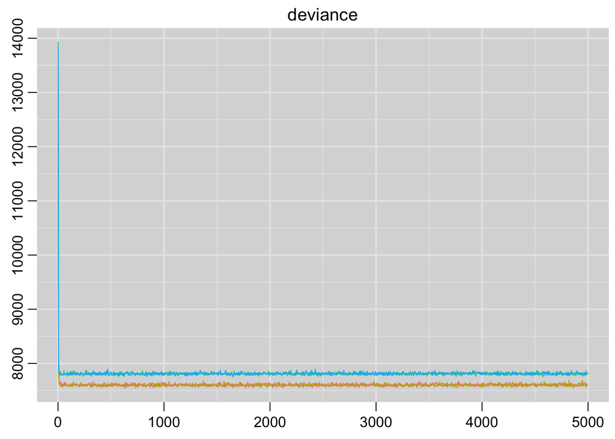

```r
traplot(mcmcout = model01.r2jags, parms = c("deviance"), greek = TRUE)
```

This complicates our life considerably as we can’t simply flip the sign of the parameters to identify the model. Further, we could have multiple parameter values for the same mode: the issue from our other models. This is called label switching in FMMs: The results are all the same, but the class labels change (e.g., 1, 2, 3, 4 become 2, 1, 3, 4).

```r
# marker item:
model02.function = function(){

  # measurement model specification
  for (person in 1:N){
    for (item in 1:I){
      X[person, item] ~ dbern(pi[item, xclass[person]])
    }
  }

  # prior distribution for class:
  for (person in 1:N){
    xclass[person] ~ dcat(eta[1:C])
  }

  # prior distribution for class probabilities:
  eta.star[1:C] ~ ddirich(alpha[1:C])

  # sort eta parameters from low to high to stop label switching
  eta[1:C] <- sort(eta.star)

  # prior distribution for the factor variance
  for (item in 1:I){
    for (class in 1:C){
      pi[item, class] ~ dbeta(a.0,b.0)
    }
  }

}

model02.r2jags =  jags.parallel(
  data = model01.data,
  parameters.to.save = model01.parameters,
  model.file = model02.function,
  n.chains = 4,
  n.iter = 10000,
  n.thin = 5,
  n.burnin = 5000,
  n.cluster = 4,
  jags.seed = model01.seed
)
model02.r2jags
```

```
## Inference for Bugs model at "model02.function", fit using jags,
##  4 chains, each with 10000 iterations (first 5000 discarded), n.thin = 5
##  n.sims = 4000 iterations saved
##              mu.vect sd.vect     2.5%      25%      50%      75%    97.5%
## eta[1]         0.169   0.016    0.136    0.158    0.171    0.181    0.197
## eta[2]         0.208   0.033    0.168    0.186    0.196    0.222    0.276
## eta[3]         0.254   0.054    0.187    0.203    0.253    0.304    0.340
## eta[4]         0.368   0.063    0.276    0.312    0.365    0.427    0.462
## pi[1,1]        0.439   0.416    0.004    0.021    0.407    0.858    0.924
## pi[2,1]        0.474   0.440    0.009    0.031    0.462    0.917    0.970
## pi[3,1]        0.447   0.429    0.004    0.016    0.364    0.883    0.957
## pi[4,1]        0.292   0.051    0.197    0.257    0.291    0.325    0.391
## pi[5,1]        0.455   0.204    0.188    0.254    0.478    0.654    0.735
## pi[6,1]        0.565   0.412    0.094    0.151    0.607    0.979    0.996
## pi[7,1]        0.208   0.202    0.001    0.007    0.161    0.404    0.500
## pi[8,1]        0.614   0.144    0.393    0.480    0.611    0.751    0.827
## pi[9,1]        0.455   0.159    0.230    0.304    0.440    0.607    0.691
## pi[10,1]       0.074   0.062    0.004    0.017    0.055    0.124    0.203
## pi[11,1]       0.084   0.048    0.022    0.048    0.070    0.110    0.202
## pi[12,1]       0.441   0.339    0.051    0.103    0.416    0.779    0.848
## pi[13,1]       0.047   0.046    0.001    0.007    0.031    0.081    0.151
## pi[14,1]       0.421   0.393    0.005    0.025    0.399    0.813    0.882
## pi[15,1]       0.230   0.203    0.009    0.028    0.184    0.428    0.519
## pi[16,1]       0.398   0.354    0.011    0.043    0.370    0.750    0.832
## pi[17,1]       0.046   0.042    0.001    0.008    0.034    0.078    0.139
## pi[18,1]       0.171   0.165    0.001    0.008    0.116    0.328    0.433
## pi[19,1]       0.053   0.050    0.000    0.007    0.039    0.091    0.160
## pi[20,1]       0.011   0.012    0.000    0.003    0.008    0.016    0.043
## pi[1,2]        0.267   0.375    0.007    0.035    0.062    0.325    0.946
## pi[2,2]        0.282   0.397    0.011    0.038    0.063    0.372    0.988
## pi[3,2]        0.240   0.393    0.001    0.006    0.015    0.287    0.951
## pi[4,2]        0.402   0.305    0.135    0.191    0.249    0.554    0.952
## pi[5,2]        0.464   0.270    0.200    0.287    0.338    0.579    0.955
## pi[6,2]        0.699   0.332    0.086    0.578    0.847    0.931    0.990
## pi[7,2]        0.255   0.372    0.001    0.024    0.054    0.343    0.943
## pi[8,2]        0.645   0.193    0.409    0.513    0.573    0.764    0.984
## pi[9,2]        0.618   0.215    0.245    0.467    0.636    0.786    0.933
## pi[10,2]       0.248   0.347    0.006    0.033    0.059    0.320    0.887
## pi[11,2]       0.352   0.355    0.028    0.116    0.198    0.479    0.981
## pi[12,2]       0.656   0.342    0.040    0.541    0.793    0.900    0.980
```

[output cut: 1199 more lines]

```
## xclass[530] 20.459     4
## xclass[531] 14.528     4
## xclass[532] 47.978     4
## xclass[533]  1.795     7
## xclass[534] 47.978     4
## xclass[535]  1.656     8
## xclass[536] 22.873     4
## deviance     7.037     4
##
## For each parameter, n.eff is a crude measure of effective sample size,
## and Rhat is the potential scale reduction factor (at convergence, Rhat=1).
##
## DIC info (using the rule, pD = var(deviance)/2)
## pD = 236.1 and DIC = 7895.5
## DIC is an estimate of expected predictive error (lower deviance is better).
```

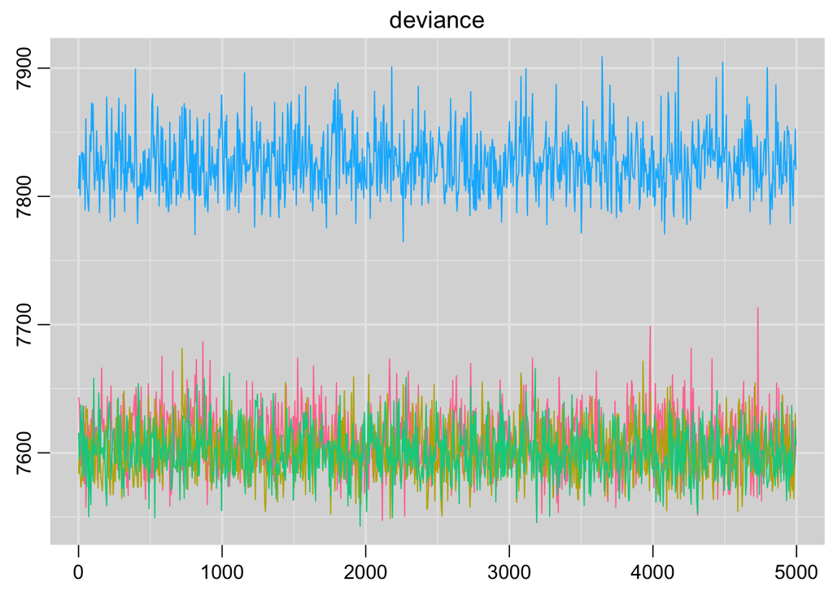

```r
traplot(mcmcout = model02.r2jags, parms = c("deviance"), greek = TRUE)
```

Here, we still see multiple modes. To further remove this problem, we can examine the chains with the lowest deviance values only. From below, we see this includes chains 1, 2, and 3.

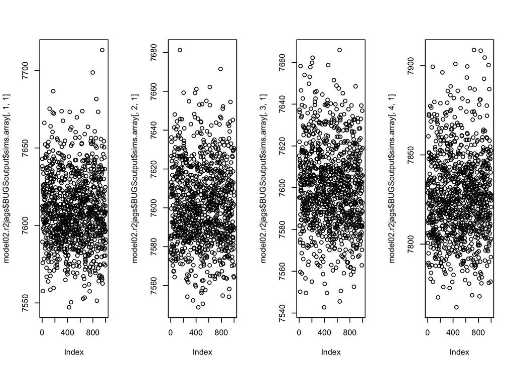

```r
par(mfrow = c(1,4))
plot(model02.r2jags$BUGSoutput$sims.array[,1,1])
plot(model02.r2jags$BUGSoutput$sims.array[,2,1])
plot(model02.r2jags$BUGSoutput$sims.array[,3,1])
plot(model02.r2jags$BUGSoutput$sims.array[,4,1])
```

So, we can now examine these chains (roughly):

```r
# convert sims.array to a mcmc.list for coda, removing [,2,]:
newChain = list()

for (i in c(1, 2, 3)){
  newChain[[length(newChain)+1]] = mcmc(model02.r2jags$BUGSoutput$sims.array[,i,])
}

newChain = mcmc.list(newChain)

# first, we can check convergence:
gelman.diag(newChain, multivariate = FALSE)
```

```
## Potential scale reduction factors:
##
##             Point est. Upper C.I.
## deviance          1.06       1.18
## eta[1]            1.66       2.65
## eta[2]            1.22       1.65
## eta[3]           10.14      19.44
## eta[4]            4.45       9.20
## pi[1,1]          29.65      75.99
## pi[2,1]          33.68      71.00
## pi[3,1]          31.02      95.79
## pi[4,1]           1.07       1.21
## pi[5,1]           6.91      13.26
## pi[6,1]          21.37      47.34
## pi[7,1]          10.70      54.09
## pi[8,1]           4.85       9.12
## pi[9,1]           5.26       9.92
## pi[10,1]          4.30      13.76
## pi[11,1]          2.68       5.50
## pi[12,1]         14.42      28.72
## pi[13,1]          3.79      13.90
## pi[14,1]         22.85      59.69
## pi[15,1]          9.79      34.74
## pi[16,1]         17.66      41.62
## pi[17,1]          3.40      10.94
## pi[18,1]          9.01      43.86
## pi[19,1]          3.88      14.22
## pi[20,1]          1.08       1.22
## pi[1,2]           1.65       2.70
## pi[2,2]           1.34       1.94
## pi[3,2]           1.21       1.59
## pi[4,2]           2.32       4.07
## pi[5,2]           1.64       2.57
## pi[6,2]          16.39      31.51
## pi[7,2]           2.14       4.03
## pi[8,2]           1.97       3.29
## pi[9,2]           6.11      11.56
## pi[10,2]          1.86       3.20
## pi[11,2]          3.69       7.13
## pi[12,2]         15.88      30.88
```

[output cut: 569 more lines]

```
## xclass[522]       3.69      12.34
## xclass[523]       2.67       8.33
## xclass[524]        Inf        NaN
## xclass[525]       7.76      17.97
## xclass[526]       3.63      11.41
## xclass[527]      66.64     416.08
## xclass[528]        Inf        NaN
## xclass[529]       2.41       6.64
## xclass[530]      11.15      23.68
## xclass[531]       5.87      18.48
## xclass[532]      16.77     104.40
## xclass[533]      16.77     104.40
## xclass[534]      16.77     104.40
## xclass[535]       7.27      20.21
## xclass[536]        Inf        NaN
```

```r
summary(newChain)
```

```
##
## Iterations = 1:1000
## Thinning interval = 1
## Number of chains = 3
## Sample size per chain = 1000
##
## 1. Empirical mean and standard deviation for each variable,
##    plus standard error of the mean:
##
##                  Mean        SD  Naive SE Time-series SE
## deviance    7.604e+03 21.497646 0.3924915      0.3850958
## eta[1]      1.697e-01  0.015128 0.0002762      0.0005004
## eta[2]      1.906e-01  0.011680 0.0002133      0.0003687
## eta[3]      2.445e-01  0.058568 0.0010693      0.0003630
## eta[4]      3.952e-01  0.048457 0.0008847      0.0005619
## pi[1,1]     3.087e-01  0.403211 0.0073616      0.0004448
## pi[2,1]     3.342e-01  0.424776 0.0077553      0.0004646
## pi[3,1]     3.164e-01  0.420286 0.0076733      0.0004879
## pi[4,1]     3.008e-01  0.048291 0.0008817      0.0008608
## pi[5,1]     3.859e-01  0.188355 0.0034389      0.0008766
## pi[6,1]     4.284e-01  0.389934 0.0071192      0.0006526
## pi[7,1]     1.463e-01  0.195978 0.0035781      0.0006425
## pi[8,1]     5.723e-01  0.141182 0.0025776      0.0009140
## pi[9,1]     4.047e-01  0.149749 0.0027340      0.0009001
## pi[10,1]    6.190e-02  0.064651 0.0011804      0.0004758
## pi[11,1]    8.635e-02  0.052125 0.0009517      0.0005838
## pi[12,1]    3.292e-01  0.319010 0.0058243      0.0007224
## pi[13,1]    3.993e-02  0.048008 0.0008765      0.0003922
## pi[14,1]    2.931e-01  0.373920 0.0068268      0.0005528
## pi[15,1]    1.636e-01  0.190132 0.0034713      0.0006267
## pi[16,1]    2.857e-01  0.340187 0.0062109      0.0006716
## pi[17,1]    3.681e-02  0.041591 0.0007593      0.0003764
## pi[18,1]    1.246e-01  0.164653 0.0030061      0.0006028
## pi[19,1]    4.123e-02  0.049404 0.0009020      0.0003862
## pi[20,1]    1.147e-02  0.011878 0.0002169      0.0002157
## pi[1,2]     5.131e-02  0.029698 0.0005422      0.0004273
## pi[2,2]     5.343e-02  0.028401 0.0005185      0.0004940
## pi[3,2]     1.375e-02  0.012873 0.0002350      0.0002191
## pi[4,2]     2.283e-01  0.063538 0.0011600      0.0007433
## pi[5,2]     3.109e-01  0.058370 0.0010657      0.0008407
```

[output cut: 1201 more lines]

```
## xclass[522] 1.000e+00 1.000e+00 1.000e+00 2.000e+00 2.000e+00
## xclass[523] 1.000e+00 1.000e+00 1.000e+00 2.000e+00 4.000e+00
## xclass[524] 1.000e+00 1.000e+00 1.000e+00 2.000e+00 2.000e+00
## xclass[525] 1.000e+00 1.000e+00 1.000e+00 2.000e+00 2.000e+00
## xclass[526] 1.000e+00 1.000e+00 1.000e+00 2.000e+00 2.000e+00
## xclass[527] 1.000e+00 1.000e+00 3.000e+00 3.000e+00 3.000e+00
## xclass[528] 1.000e+00 1.000e+00 3.000e+00 3.000e+00 3.000e+00
## xclass[529] 1.000e+00 1.000e+00 1.000e+00 2.000e+00 4.000e+00
## xclass[530] 1.000e+00 1.000e+00 1.000e+00 2.000e+00 2.000e+00
## xclass[531] 1.000e+00 1.000e+00 1.000e+00 2.000e+00 2.000e+00
## xclass[532] 1.000e+00 1.000e+00 1.000e+00 2.000e+00 2.000e+00
## xclass[533] 3.000e+00 3.000e+00 4.000e+00 4.000e+00 4.000e+00
## xclass[534] 1.000e+00 1.000e+00 1.000e+00 2.000e+00 2.000e+00
## xclass[535] 3.000e+00 3.000e+00 4.000e+00 4.000e+00 4.000e+00
## xclass[536] 1.000e+00 1.000e+00 3.000e+00 3.000e+00 3.000e+00
```

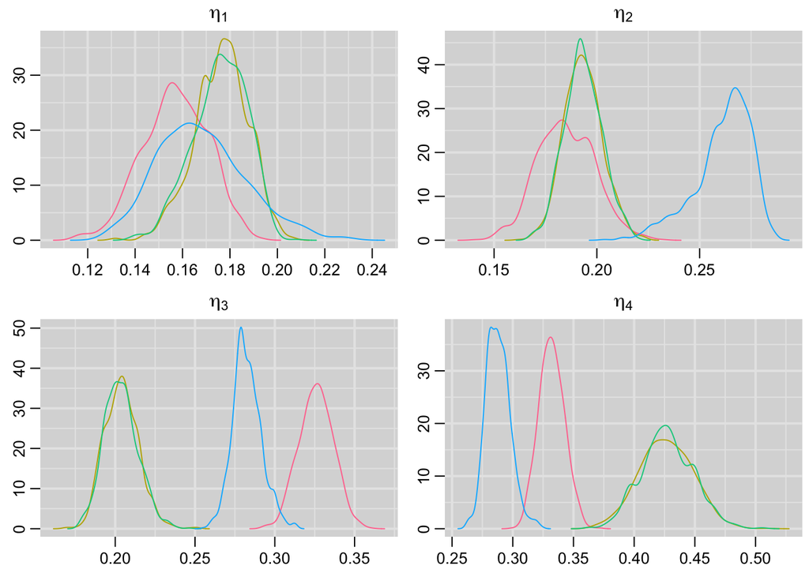

```r
# next, we can check parameters:
denplot(mcmcout = model02.r2jags, parms = c("eta"), greek = TRUE)
```

There are some who believe the multimodality of the posterior distribution is a good thing, so let’s pretend we are those people and examine all chains together:

```r
model02.r2jags
```

```
## Inference for Bugs model at "model02.function", fit using jags,
##  4 chains, each with 10000 iterations (first 5000 discarded), n.thin = 5
##  n.sims = 4000 iterations saved
##              mu.vect sd.vect     2.5%      25%      50%      75%    97.5%
## eta[1]         0.169   0.016    0.136    0.158    0.171    0.181    0.197
## eta[2]         0.208   0.033    0.168    0.186    0.196    0.222    0.276
## eta[3]         0.254   0.054    0.187    0.203    0.253    0.304    0.340
## eta[4]         0.368   0.063    0.276    0.312    0.365    0.427    0.462
## pi[1,1]        0.439   0.416    0.004    0.021    0.407    0.858    0.924
## pi[2,1]        0.474   0.440    0.009    0.031    0.462    0.917    0.970
## pi[3,1]        0.447   0.429    0.004    0.016    0.364    0.883    0.957
## pi[4,1]        0.292   0.051    0.197    0.257    0.291    0.325    0.391
## pi[5,1]        0.455   0.204    0.188    0.254    0.478    0.654    0.735
## pi[6,1]        0.565   0.412    0.094    0.151    0.607    0.979    0.996
## pi[7,1]        0.208   0.202    0.001    0.007    0.161    0.404    0.500
## pi[8,1]        0.614   0.144    0.393    0.480    0.611    0.751    0.827
## pi[9,1]        0.455   0.159    0.230    0.304    0.440    0.607    0.691
## pi[10,1]       0.074   0.062    0.004    0.017    0.055    0.124    0.203
## pi[11,1]       0.084   0.048    0.022    0.048    0.070    0.110    0.202
## pi[12,1]       0.441   0.339    0.051    0.103    0.416    0.779    0.848
## pi[13,1]       0.047   0.046    0.001    0.007    0.031    0.081    0.151
## pi[14,1]       0.421   0.393    0.005    0.025    0.399    0.813    0.882
## pi[15,1]       0.230   0.203    0.009    0.028    0.184    0.428    0.519
## pi[16,1]       0.398   0.354    0.011    0.043    0.370    0.750    0.832
## pi[17,1]       0.046   0.042    0.001    0.008    0.034    0.078    0.139
## pi[18,1]       0.171   0.165    0.001    0.008    0.116    0.328    0.433
## pi[19,1]       0.053   0.050    0.000    0.007    0.039    0.091    0.160
## pi[20,1]       0.011   0.012    0.000    0.003    0.008    0.016    0.043
## pi[1,2]        0.267   0.375    0.007    0.035    0.062    0.325    0.946
## pi[2,2]        0.282   0.397    0.011    0.038    0.063    0.372    0.988
## pi[3,2]        0.240   0.393    0.001    0.006    0.015    0.287    0.951
## pi[4,2]        0.402   0.305    0.135    0.191    0.249    0.554    0.952
## pi[5,2]        0.464   0.270    0.200    0.287    0.338    0.579    0.955
## pi[6,2]        0.699   0.332    0.086    0.578    0.847    0.931    0.990
## pi[7,2]        0.255   0.372    0.001    0.024    0.054    0.343    0.943
## pi[8,2]        0.645   0.193    0.409    0.513    0.573    0.764    0.984
## pi[9,2]        0.618   0.215    0.245    0.467    0.636    0.786    0.933
## pi[10,2]       0.248   0.347    0.006    0.033    0.059    0.320    0.887
## pi[11,2]       0.352   0.355    0.028    0.116    0.198    0.479    0.981
## pi[12,2]       0.656   0.342    0.040    0.541    0.793    0.900    0.980
```

[output cut: 1199 more lines]

```
## xclass[530] 20.459     4
## xclass[531] 14.528     4
## xclass[532] 47.978     4
## xclass[533]  1.795     7
## xclass[534] 47.978     4
## xclass[535]  1.656     8
## xclass[536] 22.873     4
## deviance     7.037     4
##
## For each parameter, n.eff is a crude measure of effective sample size,
## and Rhat is the potential scale reduction factor (at convergence, Rhat=1).
##
## DIC info (using the rule, pD = var(deviance)/2)
## pD = 236.1 and DIC = 7895.5
## DIC is an estimate of expected predictive error (lower deviance is better).
```

Now, we can examine how well this model fits the data:

```r
nObs = nrow(FSdata)

# list number of simulated data sets
nSimulatedDataSets = 5000

# create one large matrix of posterior values
model01.Posterior.all = model01.r2jags$BUGSoutput$sims.matrix
dim(model01.Posterior.all)
```

```
## [1] 4000  621
```

```r
# determine columns of posterior that go into each model matrix
colnames(model01.Posterior.all)
```

```
##   [1] "deviance"    "eta[1]"      "eta[2]"      "eta[3]"      "eta[4]"
##   [6] "pi[1,1]"     "pi[2,1]"     "pi[3,1]"     "pi[4,1]"     "pi[5,1]"
##  [11] "pi[6,1]"     "pi[7,1]"     "pi[8,1]"     "pi[9,1]"     "pi[10,1]"
##  [16] "pi[11,1]"    "pi[12,1]"    "pi[13,1]"    "pi[14,1]"    "pi[15,1]"
##  [21] "pi[16,1]"    "pi[17,1]"    "pi[18,1]"    "pi[19,1]"    "pi[20,1]"
##  [26] "pi[1,2]"     "pi[2,2]"     "pi[3,2]"     "pi[4,2]"     "pi[5,2]"
##  [31] "pi[6,2]"     "pi[7,2]"     "pi[8,2]"     "pi[9,2]"     "pi[10,2]"
##  [36] "pi[11,2]"    "pi[12,2]"    "pi[13,2]"    "pi[14,2]"    "pi[15,2]"
##  [41] "pi[16,2]"    "pi[17,2]"    "pi[18,2]"    "pi[19,2]"    "pi[20,2]"
##  [46] "pi[1,3]"     "pi[2,3]"     "pi[3,3]"     "pi[4,3]"     "pi[5,3]"
##  [51] "pi[6,3]"     "pi[7,3]"     "pi[8,3]"     "pi[9,3]"     "pi[10,3]"
##  [56] "pi[11,3]"    "pi[12,3]"    "pi[13,3]"    "pi[14,3]"    "pi[15,3]"
##  [61] "pi[16,3]"    "pi[17,3]"    "pi[18,3]"    "pi[19,3]"    "pi[20,3]"
##  [66] "pi[1,4]"     "pi[2,4]"     "pi[3,4]"     "pi[4,4]"     "pi[5,4]"
##  [71] "pi[6,4]"     "pi[7,4]"     "pi[8,4]"     "pi[9,4]"     "pi[10,4]"
```

[output cut: 110 more lines]

```r
etaCols = grep(x = colnames(model01.Posterior.all), pattern = "eta")
piCols = grep(x = colnames(model01.Posterior.all), pattern = "pi")

# save simulated covariances:
simCovModel01 = matrix(data = NA, nrow = nSimulatedDataSets, ncol = nItems*nItems)

# loop through data sets (can be sped up with functions and lapply)
pb = txtProgressBar()
sim = 1
for (sim in 1:nSimulatedDataSets){

  # draw sample from one iteration of posterior chain
  iternum = sample(x = 1:nrow(model01.Posterior.all), size = 1, replace = TRUE)

  # get parameters for that sample: put into factor model matrices for easier generation of data
  eta = model01.Posterior.all[iternum, etaCols]
  pi = matrix(data = model01.Posterior.all[iternum, piCols], ncol = C)

  # generate sample of classes from theta distribution
  class = matrix(data = sample(x = 1:C, size = nObs, replace = TRUE, prob = eta), nrow = 1)

  simData = matrix(data = NA, ncol = I, nrow = nObs)
  i=1
  for (i in 1:I){
    probs = pi[i,class]
    simData[,i] = rbinom(n = nObs, size = 1, prob = probs)
  }

  # calculate the value of SRMR using simulated data's covariance matrix and observed covariance matrix
  simCov = cov(simData)
  simCovModel01[sim,] = c(cov(simData))

  setTxtProgressBar(pb = pb, value = sim/nSimulatedDataSets)
}
close(pb)
```

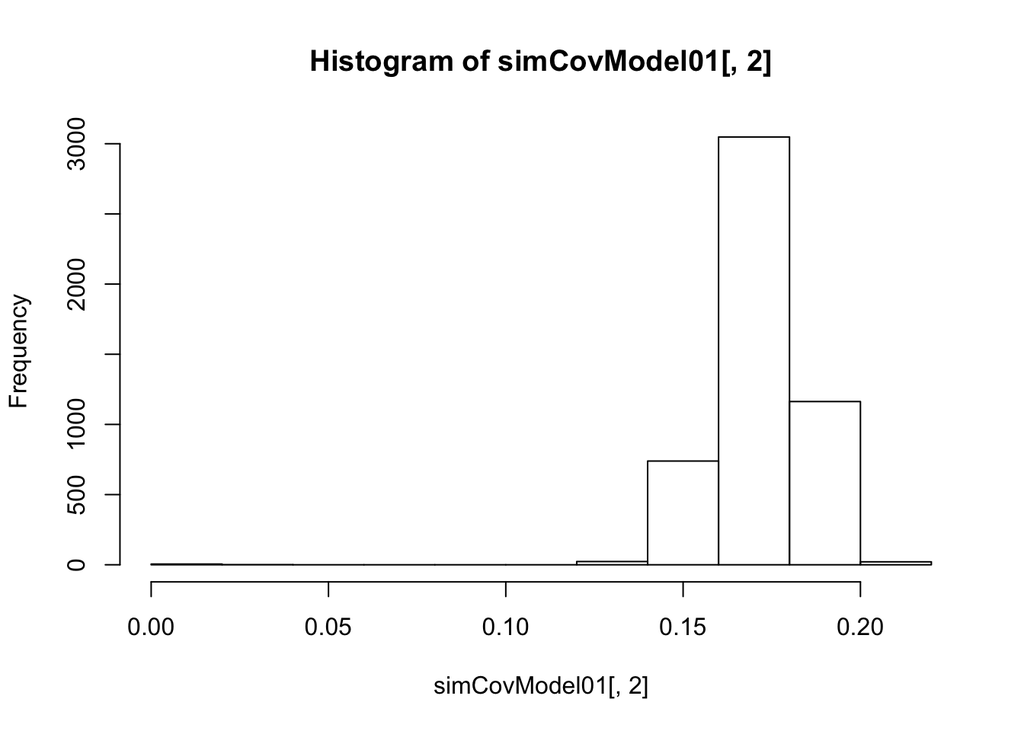

```r
# label values of simCor to ensure we have the right comparison
covNames = NULL
for (i in 1:ncol(simData)){
  for (j in 1:ncol(simData)){
    covNames = c(covNames, paste0("cov", i, "." , j))
  }
}
colnames(simCovModel01) = covNames

# show how one correlation compares to distribution of simulated correlations
dataCov = cov(FSdata)
hist(simCovModel01[,2])
```

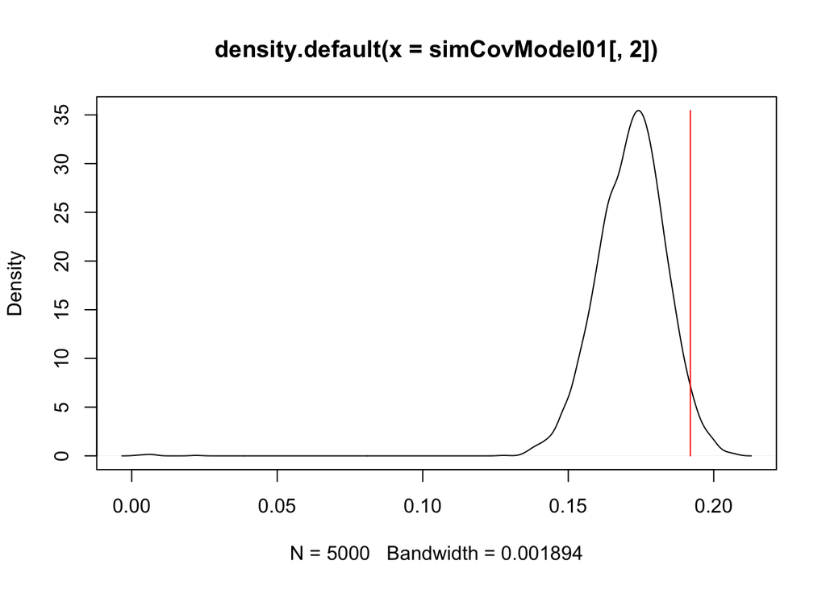

```r
plot(density(simCovModel01[,2]))
lines(x = c(dataCov[1,2], dataCov[1,2]), y = c(0, max(density(simCovModel01[,2])$y)), col = 2)
```

```r
quantile(simCovModel01[,2])
```

```
##          0%         25%         50%         75%        100%
## 0.002319012 0.164064026 0.172320059 0.179550844 0.207204631
```

```r
mean(simCovModel01[,2])
```

```
## [1] 0.1715911
```

```r
dataCov[1,2]
```

```
## [1] 0.1919619
```

```r
# create quantiles of correlations to see where each observed correlation falls
covQuantiles01 = NULL

# compute the quantiles of the observed correlations:

col = 1
for (i in 1:ncol(simData)){
  for (j in 1:ncol(simData)){
    # get empirical CDF of simulated correlation distribution
    covEcdf = ecdf(simCovModel01[,col])
    covQuantiles01 = rbind(covQuantiles01, c(i, j, summary(covEcdf), dataCov[i,j], covEcdf(dataCov[i,j])))

    col = col + 1
  }
}
colnames(covQuantiles01)[1:2] = c("Item 1", "Item 2")
colnames(covQuantiles01)[9:10] = c("ObsCor", "CorPctile")
covQuantiles01[which(covQuantiles01[,10] > .975 | covQuantiles01[,10] < .025),]
```

```
##       Item 1 Item 2          Min.    1st Qu.     Median       Mean
##  [1,]      2      3 -0.0018970568 0.17051454 0.17903299 0.17844451
##  [2,]      3      2 -0.0018970568 0.17051454 0.17903299 0.17844451
##  [3,]      4      5 -0.0177988562 0.05716976 0.06676315 0.06667796
##  [4,]      4      8 -0.0123936393 0.04793207 0.05632585 0.05632206
##  [5,]      5      4 -0.0177988562 0.05716976 0.06676315 0.06667796
##  [6,]      5      9 -0.0085507044 0.03102159 0.04025492 0.04003444
##  [7,]      7     15 -0.0007741666 0.10472521 0.11357233 0.11353348
##  [8,]      7     19 -0.0148347050 0.08835176 0.09775945 0.09742246
##  [9,]      8      4 -0.0123936393 0.04793207 0.05632585 0.05632206
## [10,]      9      5 -0.0085507044 0.03102159 0.04025492 0.04003444
## [11,]     15      7 -0.0007741666 0.10472521 0.11357233 0.11353348
## [12,]     15     19 -0.0025317339 0.09931127 0.10846004 0.10819676
## [13,]     19      7 -0.0148347050 0.08835176 0.09775945 0.09742246
## [14,]     19     15 -0.0025317339 0.09931127 0.10846004 0.10819676
##          3rd Qu.       Max.     ObsCor CorPctile
##  [1,] 0.18716261 0.21181127 0.20165992    0.9840
##  [2,] 0.18716261 0.21181127 0.20165992    0.9840
##  [3,] 0.07617607 0.11106151 0.04063677    0.0216
##  [4,] 0.06486435 0.10504952 0.10332334    0.9998
##  [5,] 0.07617607 0.11106151 0.04063677    0.0216
##  [6,] 0.04875593 0.08487934 0.07171502    0.9960
##  [7,] 0.12251709 0.15676524 0.16519738    1.0000
##  [8,] 0.10664754 0.14272911 0.14340912    1.0000
##  [9,] 0.06486435 0.10504952 0.10332334    0.9998
## [10,] 0.04875593 0.08487934 0.07171502    0.9960
## [11,] 0.12251709 0.15676524 0.16519738    1.0000
## [12,] 0.11726182 0.14927465 0.14215372    0.9976
## [13,] 0.10664754 0.14272911 0.14340912    1.0000
## [14,] 0.11726182 0.14927465 0.14215372    0.9976
```